# Analiza zbioru statystyk siatkarzy z VNL 2021-2023 i próba predykcji czy siatkarz z danymi statystykami wygra mecz, predykcja pozycji siatkarza

Adam Cwikla i Michal Szewc

2024-06-17

## Prezentacja statystyk jakie posiada jeden zawodnik

Każdy wiersz w zbiorze danych odpoiwada statystyką pojedyńczego gracza w danym meczu. W zbiorze znajduje się m.in. 1) Dane zawodnika takie jak Player_ID, Player Name = imię i nazwisko zawodnika, Position = pozycja zawodnika może to być L - libero, MB - środkowy, OH - przyjmujący, O - atakujący, S - rozgrywający, Nationality = narodowość zawodnika, Age = wiek, Height= wysokość w cm 2) Dane meczu Year = rok rozrgywanych meczy w lidze narodów, Versus = drużyna przeciwna, Match_Date = data meczu, Winner = czy mecz został wygrany 3) Statystki z meczu, statystki Serve związne z zagrywką, Set związane z rogrywaniem piłki w ataku, Attack związane z wykonanymi atakami, Block związane z blokami, Reception związane z przyjęciem, Dig związne z obronami Każda z tych statystyk posiada 4 rozwijające je pola Points/Success = zdobyte punkty zagraniem, Errors = pomyłki, Attempts = podejścia nie dające punkty ale też nie tracące Total = wszystkie Points/Succes + Errors + Attempts

```r
setwd("../")
data <- read.csv("vnl_dataset.csv")
data$Winner <- data$Winner == "True"
data$Nationality <- factor(data$Nationality)
data$Player.Name <- factor(data$Player.Name)
data$Versus <- factor(data$Versus)
data <- data[, -which(names(data) == "Total_Attacks")]
data <- data[, -which(names(data) == "Total_Blocks")]
data <- data[, -which(names(data) == "Total_Receptions")]
data <- data[, -which(names(data) == "Total_Digs")]
data <- data[, -which(names(data) == "Total_Sets")]
data <- data[, -which(names(data) == "Total_Serves")]
data <- data[data$Position != "U", ]
data$Position <- factor(data$Position)

data_woman <- read.csv("vnl_dataset_woman.csv")
data_woman$Winner <- data_woman$Winner == "True"
data_woman$Nationality <- factor(data_woman$Nationality)
data_woman$Player.Name <- factor(data_woman$Player.Name)
data_woman$Versus <- factor(data_woman$Versus)
data_woman <- data_woman[, -which(names(data_woman) == "Total_Attacks")]
data_woman <- data_woman[, -which(names(data_woman) == "Total_Blocks")]
data_woman <- data_woman[, -which(names(data_woman) == "Total_Receptions")]
data_woman <- data_woman[, -which(names(data_woman) == "Total_Digs")]
data_woman <- data_woman[, -which(names(data_woman) == "Total_Sets")]
data_woman <- data_woman[, -which(names(data_woman) == "Total_Serves")]
data_woman <- data_woman[data_woman$Position != "U", ]
data_woman$Position <- factor(data_woman$Position)

set.seed(123)
filtered_data <- data[data$Player.Name == "Sliwka Aleksander", ]
print(filtered_data)
```

```
##      Player_ID       Player.Name Position Nationality Age Height Year
## 2452    142679 Sliwka Aleksander       OH      Poland  26    196 2021
## 2453    142679 Sliwka Aleksander       OH      Poland  26    196 2021
## 2454    142679 Sliwka Aleksander       OH      Poland  26    196 2021
## 2455    142679 Sliwka Aleksander       OH      Poland  26    196 2021
## 2456    142679 Sliwka Aleksander       OH      Poland  26    196 2021
## 2457    142679 Sliwka Aleksander       OH      Poland  26    196 2021
## 2458    142679 Sliwka Aleksander       OH      Poland  26    196 2021
## 2459    142679 Sliwka Aleksander       OH      Poland  26    196 2021
## 2460    142679 Sliwka Aleksander       OH      Poland  26    196 2021
## 2461    142679 Sliwka Aleksander       OH      Poland  26    196 2021
## 2462    142679 Sliwka Aleksander       OH      Poland  26    196 2021
## 2463    142679 Sliwka Aleksander       OH      Poland  26    196 2021
## 2464    142679 Sliwka Aleksander       OH      Poland  26    196 2021
## 2465    142679 Sliwka Aleksander       OH      Poland  26    196 2021
```

[output cut: 189 more lines]

### Usunięcie niepoprawnych danych

```r
na_counts <- apply(data, 2, function(x) sum(is.na(x)))
nan_counts <- apply(data, 2, function(x) sum(is.nan(x)))
inf_counts <- apply(data, 2, function(x) sum(is.infinite(x)))

dataset <- data[complete.cases(data) & !apply(data, 1, function(x) any(is.nan(x) | is.infinite(x))), ]

data_woman$Height <- as.integer(data_woman$Height)
na_counts <- apply(data_woman, 2, function(x) sum(is.na(x)))
nan_counts <- apply(data_woman, 2, function(x) sum(is.nan(x)))
inf_counts <- apply(data_woman, 2, function(x) sum(is.infinite(x)))

dataset_woman <- data_woman[complete.cases(data_woman) & !apply(data_woman, 1, function(x) any(is.nan(x) | is.infinite(x))),]


PolandSet <- dataset[dataset$Nationality == "Poland", ]
PolandSet <- PolandSet[, sapply(PolandSet, function(x) length(unique(x)) > 1)]
```

### Największe wartości w zbiorze

```r
print_max_stats <- function(data, stat_name) {
  max_stat_value <- max(data[[stat_name]], na.rm = TRUE)

  max_stat_rows <- data[data[[stat_name]] == max_stat_value, c("Player.Name", stat_name)]

  print(max_stat_rows)
}

print_max_stats(dataset, "Serve_Points")
```

```
##               Player.Name Serve_Points
## 2380 Leon Venero Wilfredo           13
```

```r
print_max_stats(dataset, "Attack_Success")
```

```
##           Player.Name Attack_Success
## 2236 Abdel-Aziz Nimir             37
```

```r
print_max_stats(dataset, "Reception_Successful")
```

```
##        Player.Name Reception_Successful
## 2156 Dronkers Just                   21
```

```r
print_max_stats(dataset, "Block_Successful")
```

```
##            Player.Name Block_Successful
## 2934 Podrascanin Marko                8
## 6153     Loser Agustin                8
## 6675       Li Yongzhen                8
```

```r
print_max_stats(dataset, "Height")
```

```
##            Player.Name Height
## 2671 Muserskiy Dmitriy    218
## 2672 Muserskiy Dmitriy    218
## 2673 Muserskiy Dmitriy    218
## 2674 Muserskiy Dmitriy    218
## 2675 Muserskiy Dmitriy    218
## 2676 Muserskiy Dmitriy    218
## 2677 Muserskiy Dmitriy    218
```

```r
print_max_stats(dataset, "Age")
```

```
##          Player.Name Age
## 6445 Salparov Teodor  41
## 6446 Salparov Teodor  41
## 6447 Salparov Teodor  41
## 6448 Salparov Teodor  41
## 6449 Salparov Teodor  41
```

## Badanie problemu wygranych meczy

### Przeprowadzenie regresji liniowej

#### stworzenie modelu regresji liniowej

Przede wszystkim widać, że większość Nationality oraz Versus prawdopodobnie wpływa na wynik meczu. Z racji na naturę statystyk Nationality oraz Versus, mogliśmy się spodziewać, że będą one przeciwne do siebie i to się sprawdziło. Domyślnymi wartościami jest Argentyna (pierwsza alfabetycznie).

Można na podstawie tej części wyników zobaczyć, że Polska drużyna radziła sobie w tamtych czasach najlepiej, poprzez najmniejszy współczynnik przy Versus oraz największy przy Nationality (spośród wartości wpływających na wynik). Można porównać współczynniki w przypadku Nationality i Versus, ponieważ obrazują one te same dane i są proporcjonalne do siebie.

```r
model <- lm(Winner~ . -Match_Date -Player.Name -Position -Year -Dig_Attempts -Set_Successes -Reception_Attemps -Age -Player_ID,data=dataset)
summary(model)
```

```
##
## Call:
## lm(formula = Winner ~ . - Match_Date - Player.Name - Position -
##     Year - Dig_Attempts - Set_Successes - Reception_Attemps -
##     Age - Player_ID, data = dataset)
##
## Residuals:
##      Min       1Q   Median       3Q      Max
## -1.23337 -0.30194 -0.00366  0.29305  1.17334
##
## Coefficients:
##                          Estimate Std. Error t value Pr(>|t|)
## (Intercept)             0.6450839  0.0706581   9.130  < 2e-16 ***
## NationalityAustralia   -0.3931515  0.0279100 -14.086  < 2e-16 ***
## NationalityBrazil       0.1791436  0.0247637   7.234 5.11e-13 ***
## NationalityBulgaria    -0.3565009  0.0253574 -14.059  < 2e-16 ***
## NationalityCanada      -0.1924078  0.0249832  -7.701 1.50e-14 ***
## NationalityChina       -0.3112168  0.0289756 -10.741  < 2e-16 ***
## NationalityCuba        -0.1138665  0.0409249  -2.782 0.005409 **
## NationalityFrance       0.1895003  0.0246163   7.698 1.54e-14 ***
## NationalityGermany     -0.2345164  0.0256169  -9.155  < 2e-16 ***
## NationalityIran        -0.1283109  0.0254541  -5.041 4.73e-07 ***
## NationalityItaly        0.0863202  0.0244002   3.538 0.000406 ***
## NationalityJapan        0.1036126  0.0243540   4.254 2.12e-05 ***
## NationalityNetherlands -0.1627417  0.0246185  -6.611 4.07e-11 ***
## NationalityPoland       0.2905626  0.0242445  11.985  < 2e-16 ***
## NationalityRussia       0.1992373  0.0327067   6.092 1.17e-09 ***
## NationalitySerbia      -0.0027110  0.0250134  -0.108 0.913696
## NationalitySlovenia     0.0935359  0.0246657   3.792 0.000150 ***
## NationalityUSA         -0.5047084  0.0247378 -20.402  < 2e-16 ***
## Height                 -0.0007235  0.0003414  -2.119 0.034096 *
## VersusAustralia         0.3769762  0.0275263  13.695  < 2e-16 ***
## VersusBrazil           -0.1728126  0.0242726  -7.120 1.17e-12 ***
## VersusBulgaria          0.3383786  0.0248904  13.595  < 2e-16 ***
## VersusCanada            0.1811990  0.0247493   7.321 2.69e-13 ***
## VersusChina             0.2852355  0.0292251   9.760  < 2e-16 ***
## VersusCuba              0.1223292  0.0442275   2.766 0.005689 **
## VersusFrance           -0.1539956  0.0239931  -6.418 1.45e-10 ***
## VersusGermany           0.2128776  0.0252812   8.420  < 2e-16 ***
## VersusIran              0.1594373  0.0247564   6.440 1.26e-10 ***
```

[output cut: 14 more lines]

```
## Attack.Errors          -0.0336705  0.0037390  -9.005  < 2e-16 ***
## Attack_Attempts        -0.0039984  0.0020896  -1.913 0.055723 .
## Block_Successful        0.0290227  0.0051484   5.637 1.79e-08 ***
## Block_Errors           -0.0171766  0.0033911  -5.065 4.17e-07 ***
## Block_Rebounds         -0.0072787  0.0032447  -2.243 0.024906 *
## Reception_Successful    0.0017532  0.0021167   0.828 0.407543
## Reception_Errors       -0.0419874  0.0061005  -6.883 6.31e-12 ***
## Dig_Success             0.0094035  0.0020342   4.623 3.85e-06 ***
## Dig_Errors             -0.0163047  0.0037875  -4.305 1.69e-05 ***
## ---
## Signif. codes:  0 '***' 0.001 '**' 0.01 '*' 0.05 '.' 0.1 ' ' 1
##
## Residual standard error: 0.3824 on 8131 degrees of freedom
## Multiple R-squared:  0.4137, Adjusted R-squared:  0.4101
## F-statistic: 114.7 on 50 and 8131 DF,  p-value: < 2.2e-16
```

```r
model <- lm(Winner~ . -Match_Date -Player.Name -Position -Year -Dig_Attempts -Set_Successes -Reception_Attemps -Age -Player_ID,data=dataset_woman)
summary(model)
```

```
##
## Call:
## lm(formula = Winner ~ . - Match_Date - Player.Name - Position -
##     Year - Dig_Attempts - Set_Successes - Reception_Attemps -
##     Age - Player_ID, data = dataset_woman)
##
## Residuals:
##      Min       1Q   Median       3Q      Max
## -1.10012 -0.35540 -0.00647  0.34449  1.03646
##
## Coefficients:
##                                 Estimate Std. Error t value Pr(>|t|)
## (Intercept)                    0.5888511  0.1817133   3.241 0.001200 **
## NationalityBrazil              0.2550935  0.0312014   8.176 3.57e-16 ***
## NationalityBulgaria           -0.2263836  0.0343170  -6.597 4.56e-11 ***
## NationalityCanada             -0.1548456  0.0324867  -4.766 1.92e-06 ***
## NationalityChina               0.2054986  0.0315701   6.509 8.17e-11 ***
## NationalityCroatia            -0.3420563  0.0475600  -7.192 7.17e-13 ***
## NationalityDominican Republic  0.0178729  0.0318070   0.562 0.574193
## NationalityGermany            -0.1108199  0.0319090  -3.473 0.000518 ***
## NationalityItaly               0.1019259  0.0332984   3.061 0.002216 **
## NationalityJapan               0.1588672  0.0322654   4.924 8.72e-07 ***
## NationalityNetherlands         0.0001762  0.0324441   0.005 0.995667
## NationalityPoland             -0.0190723  0.0305680  -0.624 0.532697
## NationalityRussia              0.0699840  0.0411278   1.702 0.088878 .
## NationalitySerbia              0.0131344  0.0323180   0.406 0.684455
## NationalityThailand           -0.2164769  0.0327225  -6.616 4.03e-11 ***
## NationalityUSA                -0.5133255  0.0324601 -15.814  < 2e-16 ***
## Height                        -0.0006237  0.0009756  -0.639 0.522685
## VersusBrazil                  -0.2725147  0.0311794  -8.740  < 2e-16 ***
## VersusBulgaria                 0.2378983  0.0347561   6.845 8.43e-12 ***
## VersusCanada                   0.1956363  0.0325572   6.009 1.98e-09 ***
## VersusChina                   -0.1139271  0.0310061  -3.674 0.000241 ***
## VersusCroatia                  0.3956431  0.0492205   8.038 1.09e-15 ***
## VersusDominican Republic      -0.0155194  0.0320017  -0.485 0.627726
## VersusGermany                  0.1025226  0.0314295   3.262 0.001113 **
## VersusItaly                   -0.1102526  0.0310574  -3.550 0.000388 ***
## VersusJapan                   -0.0942188  0.0313956  -3.001 0.002702 **
## VersusNetherlands             -0.0010840  0.0315883  -0.034 0.972625
## VersusPoland                   0.0463177  0.0308518   1.501 0.133332
```

[output cut: 10 more lines]

```
## Attack.Errors                 -0.0325908  0.0042859  -7.604 3.32e-14 ***
## Attack_Attempts               -0.0073953  0.0018641  -3.967 7.36e-05 ***
## Block_Successful               0.0231793  0.0060909   3.806 0.000143 ***
## Block_Errors                  -0.0232121  0.0041300  -5.620 1.99e-08 ***
## Block_Rebounds                -0.0016936  0.0035297  -0.480 0.631375
## Reception_Successful           0.0018241  0.0021937   0.832 0.405701
## Reception_Errors              -0.0387234  0.0086583  -4.472 7.88e-06 ***
## Dig_Success                    0.0065021  0.0017394   3.738 0.000187 ***
## Dig_Errors                    -0.0104425  0.0041833  -2.496 0.012578 *
## ---
## Signif. codes:  0 '***' 0.001 '**' 0.01 '*' 0.05 '.' 0.1 ' ' 1
##
## Residual standard error: 0.4178 on 5924 degrees of freedom
## Multiple R-squared:  0.2983, Adjusted R-squared:  0.2929
## F-statistic: 54.76 on 46 and 5924 DF,  p-value: < 2.2e-16
```

### Dodatkowo w rozważaniach będziemy brali pod uwagę podzbiór całego zbioru będący wnikami meczów Polskich siatkarzy

```r
modelPL <- lm(Winner ~ . - Match_Date -Player.Name -Position -Height-Block_Successful -Set_Successes -Dig_Attempts -Reception_Attemps -Player_ID -Age -Attack_Attempts -Serve_Attempts -Set_Attempts -Block_Rebounds -Set_Errors, data = PolandSet)
summary(modelPL)
```

```
##
## Call:
## lm(formula = Winner ~ . - Match_Date - Player.Name - Position -
##     Height - Block_Successful - Set_Successes - Dig_Attempts -
##     Reception_Attemps - Player_ID - Age - Attack_Attempts - Serve_Attempts -
##     Set_Attempts - Block_Rebounds - Set_Errors, data = PolandSet)
##
## Residuals:
##      Min       1Q   Median       3Q      Max
## -1.08038 -0.09305  0.05606  0.25766  0.59496
##
## Coefficients:
##                        Estimate Std. Error t value Pr(>|t|)
## (Intercept)          -2.048e+02  3.936e+01  -5.204 2.74e-07 ***
## Year                  1.018e-01  1.947e-02   5.229 2.41e-07 ***
## VersusAustralia       4.043e-03  9.101e-02   0.044 0.964586
## VersusBrazil         -4.187e-01  7.694e-02  -5.442 7.90e-08 ***
## VersusBulgaria       -1.288e-02  8.848e-02  -0.146 0.884356
## VersusCanada         -3.509e-02  8.388e-02  -0.418 0.675891
## VersusChina          -4.495e-02  1.123e-01  -0.400 0.689205
## VersusFrance         -4.085e-01  8.901e-02  -4.589 5.51e-06 ***
## VersusGermany        -3.428e-02  9.689e-02  -0.354 0.723645
## VersusIran           -3.014e-01  8.206e-02  -3.673 0.000263 ***
## VersusItaly          -3.076e-01  8.048e-02  -3.822 0.000147 ***
## VersusJapan          -7.773e-02  8.470e-02  -0.918 0.359193
## VersusNetherlands    -1.787e-02  8.587e-02  -0.208 0.835260
## VersusRussia          5.322e-02  1.118e-01   0.476 0.634241
## VersusSerbia         -1.687e-01  1.071e-01  -1.575 0.115863
## VersusSlovenia       -2.197e-01  7.959e-02  -2.760 0.005968 **
## VersusUSA            -3.687e-01  7.813e-02  -4.718 3.01e-06 ***
## Serve_Points          3.536e-02  1.478e-02   2.392 0.017100 *
## Serve_Errors         -2.121e-02  1.316e-02  -1.611 0.107650
## Attack_Success        1.297e-02  5.125e-03   2.530 0.011669 *
## Attack.Errors        -3.023e-02  1.320e-02  -2.290 0.022386 *
## Block_Errors         -2.201e-02  1.041e-02  -2.114 0.034942 *
## Reception_Successful -1.315e-02  7.716e-03  -1.704 0.088903 .
## Reception_Errors     -3.709e-02  2.296e-02  -1.615 0.106793
## Dig_Success           2.581e-02  7.440e-03   3.469 0.000563 ***
## Dig_Errors           -3.008e-02  1.422e-02  -2.115 0.034871 *
## ---
## Signif. codes:  0 '***' 0.001 '**' 0.01 '*' 0.05 '.' 0.1 ' ' 1
##
## Residual standard error: 0.3384 on 558 degrees of freedom
## Multiple R-squared:  0.2739, Adjusted R-squared:  0.2414
## F-statistic: 8.419 on 25 and 558 DF,  p-value: < 2.2e-16
```

### Regresja Logistyczna

Stowrzyliśmy model regresji logistycznej, który został nauczony na 80% całości zbioru. Jak możemy zauważyć z analizy modelu znaczącę mogą być kolumny VersusAustaralia, VersusBulgaria, których wartość Estimate jest dodatnia dodatkowo warto zwrócić uwagę na VersusPoland, Attack_Errors, Reception_Errors, których wartośc Estimate jest ujemna

```r
set.seed(0)
train_indices <- sample(nrow(dataset), 0.8 * nrow(dataset))  # 80% for training
train <- dataset[train_indices, ]
test <- dataset[-train_indices, ]
train <- train[, !(names(train) %in% c("Player.Name"))]
test <- test[, !(names(test) %in% c("Player.Name"))]
logistic <- glm(Winner ~ . - Match_Date - Nationality -Position -Reception_Successful -Dig_Attempts -Set_Successes -Year -Player_ID -Reception_Attemps -Block_Rebounds, family = binomial, data = train)
summary(logistic)
```

```
##
## Call:
## glm(formula = Winner ~ . - Match_Date - Nationality - Position -
##     Reception_Successful - Dig_Attempts - Set_Successes - Year -
##     Player_ID - Reception_Attemps - Block_Rebounds, family = binomial,
##     data = train)
##
## Coefficients:
##                    Estimate Std. Error z value Pr(>|z|)
## (Intercept)        1.604744   0.551754   2.908 0.003632 **
## Age                0.034381   0.007095   4.846 1.26e-06 ***
## Height            -0.014118   0.002552  -5.532 3.16e-08 ***
## VersusAustralia    2.026720   0.213491   9.493  < 2e-16 ***
## VersusBrazil      -0.823204   0.155856  -5.282 1.28e-07 ***
## VersusBulgaria     1.580211   0.168595   9.373  < 2e-16 ***
## VersusCanada       0.785629   0.154033   5.100 3.39e-07 ***
## VersusChina        1.351624   0.197650   6.838 8.00e-12 ***
## VersusCuba         0.756921   0.262263   2.886 0.003900 **
## VersusFrance      -0.673946   0.152476  -4.420 9.87e-06 ***
## VersusGermany      0.883195   0.155863   5.666 1.46e-08 ***
## VersusIran         0.700450   0.153855   4.553 5.30e-06 ***
## VersusItaly       -0.554903   0.147430  -3.764 0.000167 ***
## VersusJapan       -0.685129   0.151330  -4.527 5.97e-06 ***
## VersusNetherlands  0.536188   0.149869   3.578 0.000347 ***
## VersusPoland      -1.605850   0.174050  -9.226  < 2e-16 ***
## VersusRussia      -0.740933   0.208290  -3.557 0.000375 ***
## VersusSerbia      -0.073854   0.149639  -0.494 0.621624
## VersusSlovenia    -0.204340   0.150053  -1.362 0.173266
## VersusUSA         -0.635935   0.155202  -4.097 4.18e-05 ***
## Serve_Points       0.251617   0.044240   5.688 1.29e-08 ***
## Serve_Errors      -0.063790   0.028573  -2.233 0.025581 *
## Serve_Attempts     0.040960   0.010124   4.046 5.22e-05 ***
## Set_Errors        -0.342546   0.114118  -3.002 0.002685 **
## Set_Attempts      -0.007019   0.002761  -2.542 0.011021 *
## Attack_Success     0.089292   0.012539   7.121 1.07e-12 ***
## Attack.Errors     -0.217637   0.026890  -8.094 5.79e-16 ***
## Attack_Attempts   -0.036909   0.014450  -2.554 0.010643 *
## Block_Successful   0.186229   0.035007   5.320 1.04e-07 ***
## Block_Errors      -0.141393   0.022184  -6.374 1.85e-10 ***
## Reception_Errors  -0.343669   0.043145  -7.965 1.65e-15 ***
## Dig_Success        0.082052   0.012947   6.338 2.33e-10 ***
## Dig_Errors        -0.130733   0.026399  -4.952 7.34e-07 ***
## ---
## Signif. codes:  0 '***' 0.001 '**' 0.01 '*' 0.05 '.' 0.1 ' ' 1
##
## (Dispersion parameter for binomial family taken to be 1)
##
##     Null deviance: 9018.8  on 6544  degrees of freedom
## Residual deviance: 7428.7  on 6512  degrees of freedom
## AIC: 7494.7
##
## Number of Fisher Scoring iterations: 4
```

przeprowadzamy teraz predykcję jeśli wartość przewidywana jest większa od 0.5 oznacza to że dana drużyna wygrywa mecz

```r
predictions <- predict(logistic, newdata = test, type = "response")
predicted_classes <- ifelse(predictions > 0.5, 1, 0)
cm <- table(Actual = test$Winner, Predicted = predicted_classes)
print(cm)
```

```
##        Predicted
## Actual    0   1
##   FALSE 691 205
##   TRUE  287 454
```

```r
accuracy <- sum(diag(cm)) / sum(cm)
cat("Accuracy:", accuracy, "\n")
```

```
## Accuracy: 0.6994502
```

```r
sensitivity <- cm[2, 2] / sum(cm[2, ])
cat("Sensitivity (TPR):", sensitivity, "\n")
```

```
## Sensitivity (TPR): 0.6126856
```

```r
specificity <- cm[1, 1] / sum(cm[1, ])
cat("Specificity (TNR):", specificity, "\n")
```

```
## Specificity (TNR): 0.7712054
```

```r
library(pROC)
```

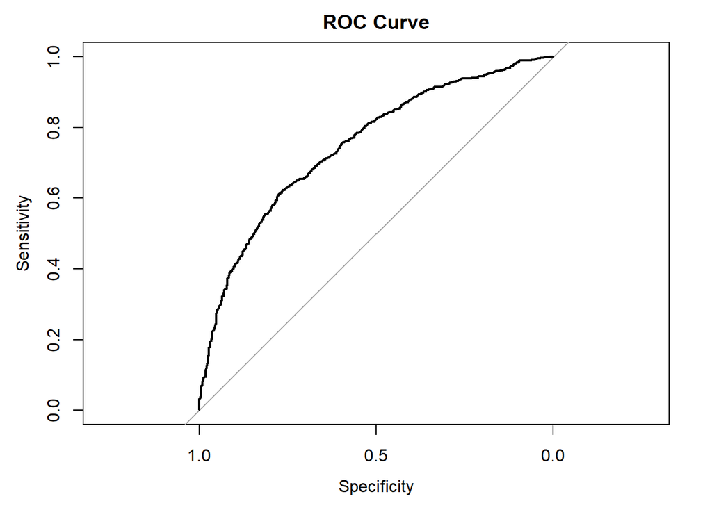

```r
roc_curve <- roc(test$Winner, predictions)
plot(roc_curve, main = "ROC Curve")
```

```r
train_indices_PL <- sample(nrow(PolandSet), 0.8 * nrow(PolandSet))  # 80% for training
train_PL <- PolandSet[train_indices_PL, ]
test_PL <- PolandSet[-train_indices_PL, ]
logisticPL <- glm(Winner ~ . - Match_Date -Player.Name -Position
                  -Age -Height -Player_ID -Set_Successes -Set_Attempts -Versus  -Block_Successful -Dig_Attempts -Serve_Attempts -Block_Rebounds -Attack_Attempts -Reception_Errors -Reception_Errors -Reception_Attemps, family = binomial, data = train_PL)
summary(logisticPL)
```

```
##
## Call:
## glm(formula = Winner ~ . - Match_Date - Player.Name - Position -
##     Age - Height - Player_ID - Set_Successes - Set_Attempts -
##     Versus - Block_Successful - Dig_Attempts - Serve_Attempts -
##     Block_Rebounds - Attack_Attempts - Reception_Errors - Reception_Errors -
##     Reception_Attemps, family = binomial, data = train_PL)
##
## Coefficients:
##                        Estimate Std. Error z value Pr(>|z|)
## (Intercept)          -1.211e+03  3.517e+02  -3.445 0.000572 ***
## Year                  5.999e-01  1.740e-01   3.449 0.000563 ***
## Serve_Points          4.156e-01  1.854e-01   2.242 0.024977 *
## Serve_Errors         -1.985e-01  1.109e-01  -1.791 0.073335 .
## Set_Errors           -6.899e-01  6.064e-01  -1.138 0.255221
## Attack_Success        1.277e-01  4.901e-02   2.605 0.009185 **
## Attack.Errors        -3.222e-01  1.101e-01  -2.926 0.003429 **
## Block_Errors         -1.313e-01  9.047e-02  -1.451 0.146769
## Reception_Successful -1.488e-01  6.261e-02  -2.377 0.017446 *
## Dig_Success           2.497e-01  7.965e-02   3.135 0.001719 **
## Dig_Errors           -3.279e-01  1.277e-01  -2.567 0.010251 *
## ---
## Signif. codes:  0 '***' 0.001 '**' 0.01 '*' 0.05 '.' 0.1 ' ' 1
##
## (Dispersion parameter for binomial family taken to be 1)
##
##     Null deviance: 463.47  on 466  degrees of freedom
## Residual deviance: 416.51  on 456  degrees of freedom
## AIC: 438.51
##
## Number of Fisher Scoring iterations: 5
```

przeprowadzamy predykcję dla zbioru PolandSet, jak będzie widać ponizej wartość accuracy tego modelu jest na dosyć wysokim poziomie.

```r
predictions <- predict(logisticPL, newdata = test_PL, type = "response")
predicted_classes <- ifelse(predictions > 0.5, 1, 0)
cm <- table(Actual = test_PL$Winner, Predicted = predicted_classes)
print(cm)
```

```
##        Predicted
## Actual    0   1
##   FALSE   2  14
##   TRUE    1 100
```

```r
accuracy <- sum(diag(cm)) / sum(cm)
cat("Accuracy:", accuracy, "\n")
```

```
## Accuracy: 0.8717949
```

```r
sensitivity <- cm[2, 2] / sum(cm[2, ])
cat("Sensitivity (TPR):", sensitivity, "\n")
```

```
## Sensitivity (TPR): 0.990099
```

```r
specificity <- cm[1, 1] / sum(cm[1, ])
cat("Specificity (TNR):", specificity, "\n")
```

```
## Specificity (TNR): 0.125
```

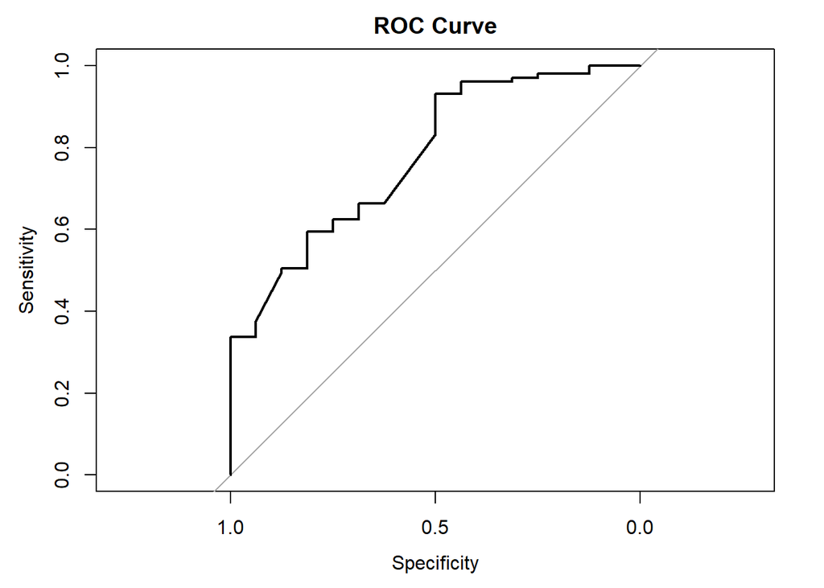

```r
library(pROC)
roc_curve <- roc(test_PL$Winner, predictions)
plot(roc_curve, main = "ROC Curve")
```

### Las

```r
#install.packages("randomForest")
library(randomForest)
```

### Stworzenie drzewa dla zbioru wyników wszystkich meczy

W celu testowania i trenowania zbioru tworzymy nowe zbiory testowe, specjalnie dla random forest. Tworzymy dwa modele jeden z dla całego zbioru drugi dla zbioru meczów Polaków. Dla każdego modelu wyliczamy MSE. Wynosi on w przybliżeniu 0.1 co jest stosunkowo dużo dla przewidywnych wartości z przediału 0-1

```r
train_rf <- sample(1:nrow(dataset), 0.8 * nrow(dataset))
test_rf <- setdiff(1:nrow(dataset), train_rf)

rf <- randomForest(Winner ~ . - Match_Date -Player.Name -Player_ID, data = dataset, subset = train_rf, importance = TRUE)
pred_rf <- predict(rf, newdata = dataset[test_rf, ])

mse_rf <- mean((pred_rf - dataset$Winner[test_rf])^2)
print(rf)
```

```
##
## Call:
##  randomForest(formula = Winner ~ . - Match_Date - Player.Name -      Player_ID, data = dataset, importance = TRUE, subset = train_rf)
##                Type of random forest: regression
##                      Number of trees: 500
## No. of variables tried at each split: 8
##
##           Mean of squared residuals: 0.1061327
##                     % Var explained: 57.15
```

```r
print(mse_rf)
```

```
## [1] 0.1050642
```

### Stworzenie modelu randomForest dla zbioru Polskich zawodników

```r
trainPL_rf <- sample(1:nrow(PolandSet), 0.8 * nrow(PolandSet))
testPL_rf <- setdiff(1:nrow(PolandSet), trainPL_rf)

rfPL <- randomForest(Winner ~ . - Match_Date -Player.Name -Player_ID, data = PolandSet, subset = trainPL_rf, importance = TRUE)
pred_rfPL <- predict(rfPL, newdata = PolandSet[testPL_rf, ])

mse_rfPL <- mean((pred_rfPL - PolandSet$Winner[testPL_rf])^2)
print(rfPL)
```

```
##
## Call:
##  randomForest(formula = Winner ~ . - Match_Date - Player.Name -      Player_ID, data = PolandSet, importance = TRUE, subset = trainPL_rf)
##                Type of random forest: regression
##                      Number of trees: 500
## No. of variables tried at each split: 7
##
##           Mean of squared residuals: 0.1100082
##                     % Var explained: 26.11
```

```r
print(mse_rfPL)
```

```
## [1] 0.1107447
```

#### Wyniki dla zbioru wszystkich siatkarzy

Teraz wyświetlimy wartości jakie model przewidziaj w porównaniu z prawdziwymi oraz policzymy jego dokładność zarówno dla zbioru pełnego jak i Polskiego.

```r
pred_rf_binary <- ifelse(pred_rf > 0.5, 1, 0)

conf_matrix <- table(Predicted = pred_rf_binary, Actual = dataset$Winner[test_rf])

print(conf_matrix)
```

```
##          Actual
## Predicted FALSE TRUE
##         0   770  116
##         1   111  640
```

```r
accuracy <- sum(diag(conf_matrix)) / sum(conf_matrix)
print(paste("Accuracy:", round(accuracy, 4)))
```

```
## [1] "Accuracy: 0.8613"
```

```r
pred_rf_binary_w <- ifelse(pred_rf > 0.5, 1, 0)

conf_matrix_w <- table(Predicted = pred_rf_binary_w, Actual = data_woman$Winner[test_rf])

print(conf_matrix_w)
```

```
##          Actual
## Predicted FALSE TRUE
##         0   364  287
##         1   320  238
```

```r
accuracy_w <- sum(diag(conf_matrix_w)) / sum(conf_matrix_w)
print(paste("Accuracy:", round(accuracy_w, 4)))
```

```
## [1] "Accuracy: 0.4979"
```

```r
importance(rf)
```

```
##                         %IncMSE IncNodePurity
## Position              -3.536402     29.125721
## Nationality          155.711931    491.310689
## Age                    6.399892     59.205213
## Height                -0.352933     56.170777
## Year                  46.254986     54.524470
## Versus               130.067597    418.178500
## Serve_Points          13.672243     15.879287
## Serve_Errors          19.933241     20.719666
## Serve_Attempts        33.060976     49.458365
## Set_Successes         12.594440     13.105505
## Set_Errors             5.789190      4.851153
## Set_Attempts          15.755963     28.189773
## Attack_Success        25.516587     30.966088
## Attack.Errors         21.634837     21.480277
## Attack_Attempts       24.593602     26.729796
## Block_Successful      18.032263     19.696507
## Block_Errors          17.690738     21.638209
## Block_Rebounds        15.012313     20.458678
## Reception_Successful  13.765208     18.553745
## Reception_Errors      17.561710     16.064228
## Reception_Attemps     20.051714     25.460389
## Dig_Success           20.622488     31.360271
## Dig_Errors            18.885556     23.646249
## Dig_Attempts           8.880398     13.635845
```

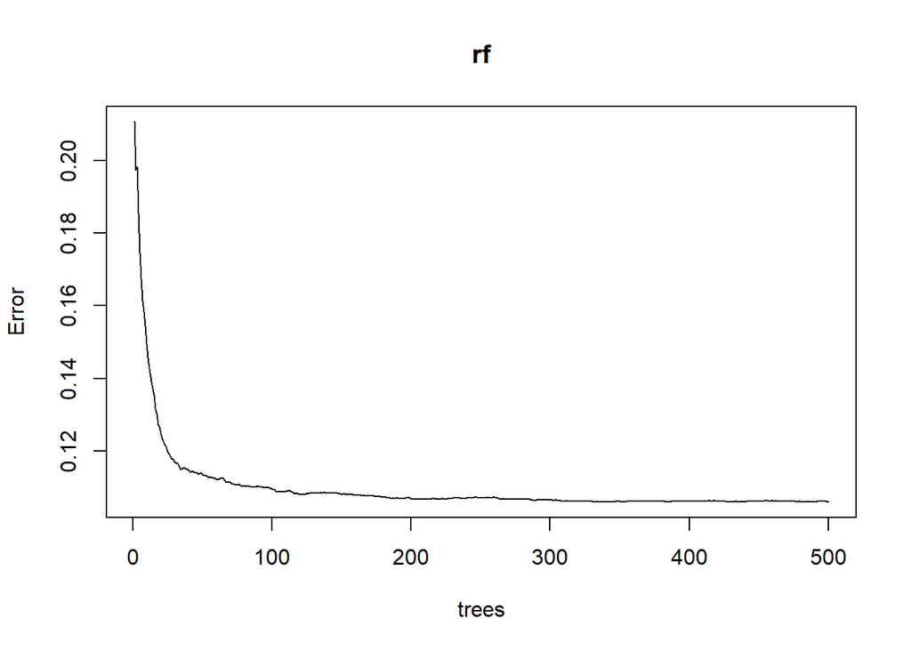

```r
plot(rf, type = "l")
```

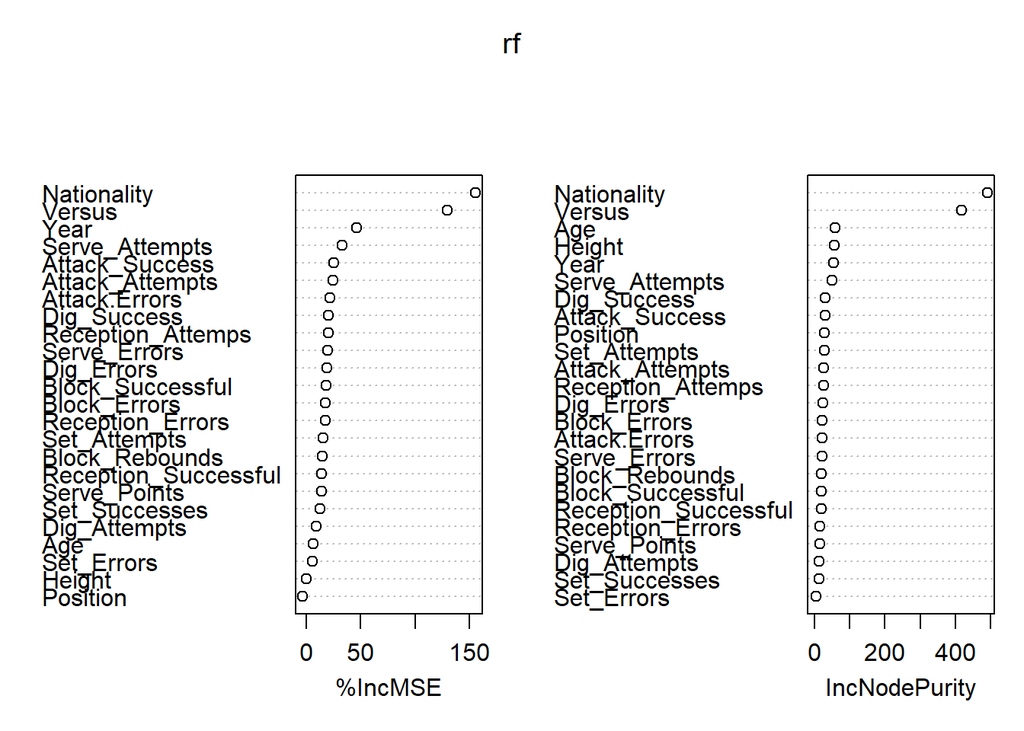

```r
varImpPlot(rf)
```

#### Wyniki dla zbioru Polskich siatkarzy

```r
pred_rf_binaryPL <- ifelse(pred_rfPL > 0.5, 1, 0)

conf_matrixPL <- table(Predicted = pred_rf_binaryPL, Actual = PolandSet$Winner[testPL_rf])

print(conf_matrixPL)
```

```
##          Actual
## Predicted FALSE TRUE
##         0     7    3
##         1    16   91
```

```r
accuracyPL <- sum(diag(conf_matrixPL)) / sum(conf_matrixPL)
print(paste("Accuracy:", round(accuracyPL, 4)))
```

```
## [1] "Accuracy: 0.8376"
```

```r
importance(rfPL)
```

```
##                         %IncMSE IncNodePurity
## Position             -6.9278393     1.8129916
## Age                  -3.5768162     3.4235009
## Height               -5.0212463     2.6480923
## Year                 23.4495022     4.7024447
## Versus               35.8411786    20.0064398
## Serve_Points          4.0818215     0.9901646
## Serve_Errors          3.9836546     1.4591902
## Serve_Attempts        6.4387033     2.6445621
## Set_Successes        -1.3892910     0.8784358
## Set_Errors            0.3640067     0.2512987
## Set_Attempts          5.4944647     2.7623458
## Attack_Success        4.1681838     1.7704935
## Attack.Errors         1.0344016     1.3836909
## Attack_Attempts       5.0847034     1.8109351
## Block_Successful      1.1625382     0.9537991
## Block_Errors         11.0015969     2.1766115
## Block_Rebounds        6.4947955     1.6587875
## Reception_Successful  5.3907528     1.9712863
## Reception_Errors      4.7109286     1.1991831
## Reception_Attemps     4.2961119     2.0219876
## Dig_Success           5.4419468     1.9391040
## Dig_Errors            6.2882687     1.9486658
## Dig_Attempts          1.2901946     0.8943881
```

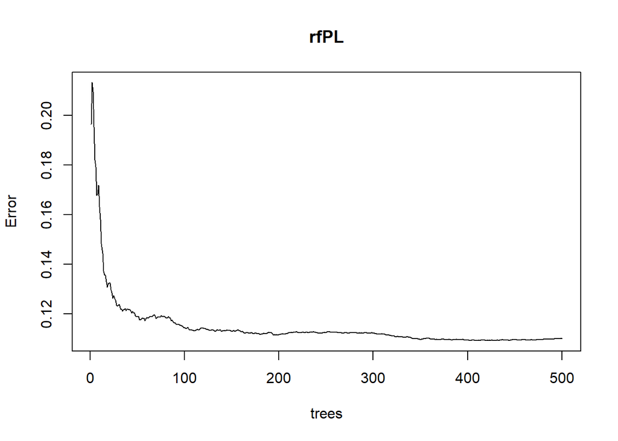

```r
plot(rfPL, type = "l")
```

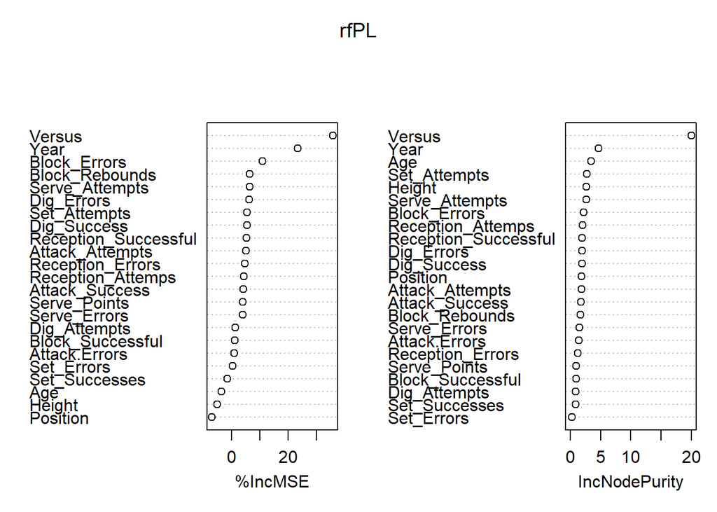

```r
varImpPlot(rfPL)
```

## Badanie pozycji

### KNN

```r
library(class)
```

```r
train_knn <- train[, !(names(train) %in% c("Versus","Match_Date","Nationality","Winner","Position"))]
test_knn <- test[, !(names(test) %in% c("Versus","Match_Date","Nationality","Winner","Position"))]
class_knn <- dataset$Position[train_indices]
knn_pos <- knn(train = train_knn, test = test_knn, cl = class_knn, k=3)

summary(knn_pos)
```

```
##   L  MB   O  OH   S
## 236 442 209 517 233
```

```r
class_knn_test <- dataset$Position[-train_indices]
t <- table(knn_pos,class_knn_test)

accuracy <- sum(diag(t)) / sum(t)
print(t)
```

```
##        class_knn_test
## knn_pos   L  MB   O  OH   S
##      L  233   0   0   0   3
##      MB   0 433   2   7   0
##      O    0   0 206   1   2
##      OH   0   0   1 515   1
##      S    0   0   1   2 230
```

```r
print(paste("Accuracy:", accuracy))
```

```
## [1] "Accuracy: 0.987782529016494"
```

```r
knn_pos5 <- knn(train = train_knn, test = test_knn, cl = class_knn, k=5)

summary(knn_pos5)
```

```
##   L  MB   O  OH   S
## 243 436 213 518 227
```

```r
class_knn_test <- dataset$Position[-train_indices]
t <- table(knn_pos5,class_knn_test)

accuracy <- sum(diag(t)) / sum(t)
print(t)
```

```
##         class_knn_test
## knn_pos5   L  MB   O  OH   S
##       L  233   1   0   1   8
##       MB   0 426   2   5   3
##       O    0   1 206   1   5
##       OH   0   5   1 509   3
##       S    0   0   1   9 217
```

```r
print(paste("Accuracy:", accuracy))
```

```
## [1] "Accuracy: 0.971899816737935"
```

```r
train_knn_PL <- train_PL[, !(names(train_PL) %in% c("Versus","Match_Date","Winner","Position", "Player.Name"))]
test_knn_PL <- test_PL[, !(names(test_PL) %in% c("Versus","Match_Date","Winner","Position", "Player.Name"))]
class_knn_PL <- PolandSet$Position[train_indices_PL]
knn_pos_PL <- knn(train = train_knn_PL, test = test_knn_PL, cl = class_knn_PL, k=3)

summary(knn_pos_PL)
```

```
##  L MB  O OH  S
## 17 28 18 34 20
```

```r
class_knn_test_PL <- PolandSet$Position[-train_indices_PL]
t_PL <- table(knn_pos_PL,class_knn_test_PL)

accuracy_PL <- sum(diag(t_PL)) / sum(t_PL)
print(t_PL)
```

```
##           class_knn_test_PL
## knn_pos_PL  L MB  O OH  S
##         L  17  0  0  0  0
##         MB  0 27  0  1  0
##         O   0  2 16  0  0
##         OH  0  0  0 33  1
##         S   0  0  0  1 19
```

```r
print(paste("Accuracy:", accuracy_PL))
```

```
## [1] "Accuracy: 0.957264957264957"
```

### Las losowy

```r
set.seed(123)
rf_pos <- randomForest(Position ~ . - Match_Date -Player.Name -Player_ID -Versus -Nationality -Winner, data = dataset, subset = train_rf, importance = TRUE)

pred_rf_pos <- predict(rf_pos, newdata = dataset[test_rf, ])
conf_matrix_pos <- table(Predicted = pred_rf_pos, Actual = dataset$Position[test_rf])

print(conf_matrix_pos)
```

```
##          Actual
## Predicted   L  MB   O  OH   S
##        L  201   0   1   6  13
##        MB   2 381  38  22   4
##        O    0  15 108   7   0
##        OH  10  34  27 528  35
##        S    0   0   0   0 205
```

```r
accuracy_pos <- sum(diag(conf_matrix_pos)) / sum(conf_matrix_pos)
print(paste("Accuracy:", round(accuracy_pos, 4)))
```

```
## [1] "Accuracy: 0.8693"
```

Dla kobiet

```r
pred_rf_pos_w <- predict(rf_pos, newdata = dataset_woman[test_rf, ])
conf_matrix_pos_w <- table(Predicted = pred_rf_pos_w, Actual = dataset_woman$Position[test_rf])

print(conf_matrix_pos_w)
```

```
##          Actual
## Predicted   L  MB   O  OH   S
##        L  152  41  19  70  23
##        MB   0 143   5   4   1
##        O    0  38  66  21   0
##        OH   7  83  36 261   2
##        S    3  14   3  26 161
```

```r
accuracy_pos_w<- sum(diag(conf_matrix_pos_w)) / sum(conf_matrix_pos_w)
print(paste("Accuracy:", round(accuracy_pos_w, 4)))
```

```
## [1] "Accuracy: 0.6641"
```

```r
importance(rf_pos)
```

```
##                              L        MB           O        OH         S
## Age                  28.968221 40.905795 32.33435291 56.053353 27.095568
## Height               81.546603 69.967319 33.72215565 82.779208 31.996566
## Year                 14.348111 17.714099 16.28311860 22.197106 14.432887
## Serve_Points          7.656217  8.320687  0.36746233  8.079458  9.626759
## Serve_Errors         24.757882 21.150412  7.57783940 17.130572  3.034299
## Serve_Attempts       42.969283 42.026047 15.82147105 24.227805  9.382160
## Set_Successes        26.924578 42.035610 20.25911654 48.906009 30.587985
## Set_Errors            4.543145  7.588108 -0.02956949  6.088238 -1.346248
## Set_Attempts         34.400275 56.597103 14.41877053 55.232831 27.113203
## Attack_Success       27.725627 44.886556 22.61192547 26.630999 26.616900
## Attack.Errors        18.098172 41.381240 28.19212701 17.422847 16.485325
## Attack_Attempts      21.692045 45.247798 21.73872617 21.280294 23.618538
## Block_Successful     10.547546 16.217596  2.29383641 19.082982  7.035452
## Block_Errors         20.789015 41.478559 -5.54528108 28.223656  6.259736
## Block_Rebounds       14.372600 26.347631 -8.58051031 21.302896  9.402472
## Reception_Successful 14.954149 28.463423 33.56930103 28.682076 25.382408
## Reception_Errors     13.610374 26.859192 20.47252703  6.016462 14.379302
## Reception_Attemps    18.579494 75.995915 75.98882232 63.474255 31.425221
## Dig_Success          10.714269 24.979570 14.37508868 20.601962  9.211527
## Dig_Errors            9.173045 17.253408  7.62619936 10.364133  2.679011
## Dig_Attempts         -3.658127 11.984289  4.66346131  5.595023  5.469158
##                      MeanDecreaseAccuracy MeanDecreaseGini
## Age                             63.395612       217.454869
## Height                          98.734848       834.374317
## Year                            31.939497        53.573624
## Serve_Points                    14.699378        22.350203
## Serve_Errors                    34.922346        86.922973
## Serve_Attempts                  56.722336       271.960636
## Set_Successes                   42.120857       348.162174
## Set_Errors                       8.872382         7.864186
## Set_Attempts                    56.116811       339.616368
## Attack_Success                  48.619201       274.045348
## Attack.Errors                   43.825756       214.225110
## Attack_Attempts                 47.097724       250.222815
## Block_Successful                22.981745        60.825582
## Block_Errors                    42.384060       158.707395
## Block_Rebounds                  28.607777       106.158055
## Reception_Successful            41.538689       232.608170
## Reception_Errors                27.735848       104.947251
## Reception_Attemps               84.419465       486.995232
## Dig_Success                     36.396777       101.387315
## Dig_Errors                      24.614353        49.776221
## Dig_Attempts                    13.716873        20.726108
```

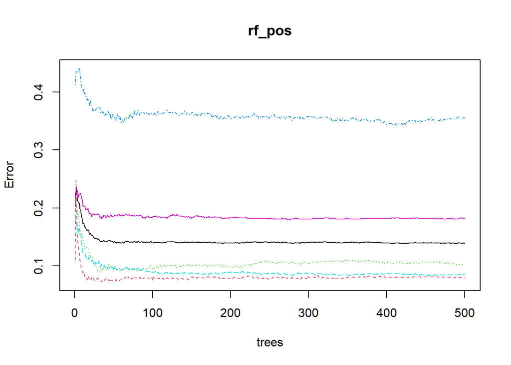

```r
plot(rf_pos, type = "l")
```

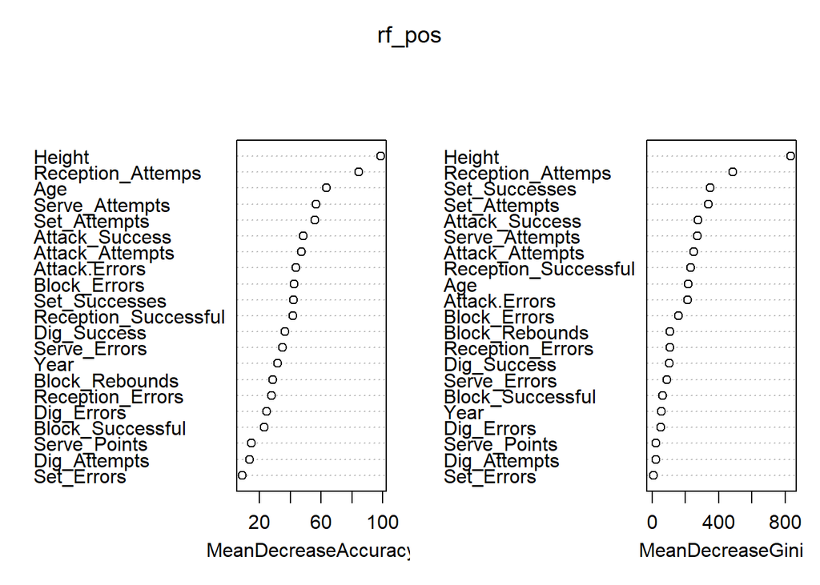

```r
varImpPlot(rf_pos)
```